# Investigating Red Wine dataset by Adam McCarthy

> **Dataset**: Red wine dataset consiting of 1599 variants of the Portuguese “Vinho Verde” wine. Includes physicochemical (inputs) and sensory (the output) variables. This dataset is public available for research. The details are described in [Cortez et al., 2009].

# Univariate Plots Section

> **Overview**: There are 13 variables within the original dataset. Of these one is a dependent variable giving a subjective measure of quality based on experts sensory reviw of the wine. The main 11 variables are independent physiochemical tests. These may be inter-related but are initially thought of as individual measurements.

See [here](https://s3.amazonaws.com/udacity-hosted-downloads/ud651/wineQualityInfo.txt) for more information.

- X - Each row of data, each wine type tested. - Index

Input variables (based on physicochemical tests):

- 1 - fixed acidity, tartaric acid - $(g/dm^{3})$
- 2 - volatile acidity, acetic acid - $(g/dm^{3})$
- 3 - citric acid - $(g/dm^{3})$
- 4 - residual sugar - $(g/dm^{3})$
- 5 - chlorides, sodium chloride - $(g/dm^{3})$
- 6 - free sulfur dioxide $(mg/dm^{3})$
- 7 - total sulfur dioxide $(mg/dm^{3})$
- 8 - density $(g/cm^{3})$
- 9 - pH
- 10 - sulphates, potassium sulphate - $(g/dm^{3})$
- 11 - alcohol (% by volume)

Output variable (based on sensory data):

- 12 - quality (score between 0 and 10)
- 13 - quality_c (quality grouped into lower and upper)

```
##        X          fixed.acidity   volatile.acidity  citric.acid
##  Min.   :   1.0   Min.   : 4.60   Min.   :0.1200   Min.   :0.000
##  1st Qu.: 400.5   1st Qu.: 7.10   1st Qu.:0.3900   1st Qu.:0.090
##  Median : 800.0   Median : 7.90   Median :0.5200   Median :0.260
##  Mean   : 800.0   Mean   : 8.32   Mean   :0.5278   Mean   :0.271
##  3rd Qu.:1199.5   3rd Qu.: 9.20   3rd Qu.:0.6400   3rd Qu.:0.420
##  Max.   :1599.0   Max.   :15.90   Max.   :1.5800   Max.   :1.000
##  residual.sugar     chlorides       free.sulfur.dioxide
##  Min.   : 0.900   Min.   :0.01200   Min.   : 1.00
##  1st Qu.: 1.900   1st Qu.:0.07000   1st Qu.: 7.00
##  Median : 2.200   Median :0.07900   Median :14.00
##  Mean   : 2.539   Mean   :0.08747   Mean   :15.87
##  3rd Qu.: 2.600   3rd Qu.:0.09000   3rd Qu.:21.00
##  Max.   :15.500   Max.   :0.61100   Max.   :72.00
##  total.sulfur.dioxide    density             pH          sulphates
##  Min.   :  6.00       Min.   :0.9901   Min.   :2.740   Min.   :0.3300
##  1st Qu.: 22.00       1st Qu.:0.9956   1st Qu.:3.210   1st Qu.:0.5500
##  Median : 38.00       Median :0.9968   Median :3.310   Median :0.6200
##  Mean   : 46.47       Mean   :0.9967   Mean   :3.311   Mean   :0.6581
##  3rd Qu.: 62.00       3rd Qu.:0.9978   3rd Qu.:3.400   3rd Qu.:0.7300
##  Max.   :289.00       Max.   :1.0037   Max.   :4.010   Max.   :2.0000
##     alcohol         quality      quality_c
##  Min.   : 8.40   Min.   :3.000   lower:744
##  1st Qu.: 9.50   1st Qu.:5.000   upper:855
##  Median :10.20   Median :6.000
##  Mean   :10.42   Mean   :5.636
##  3rd Qu.:11.10   3rd Qu.:6.000
##  Max.   :14.90   Max.   :8.000
```

The summary table depicts descriptive statistics for all of the variables.

One categorical variables within the dataset is generated to group quality into two categories. Lower (<=5) and Upper (>5). This will be used to explore for any major differences in values.

Ph is on a scale of 0 to 14 (potential of hydrogen), all values here are acidic (<7) with the range occuring between 2.7-4.

Alcholol is measured in percentages.

The other variables are all numeric data types.

There are no missing values within the dataset.

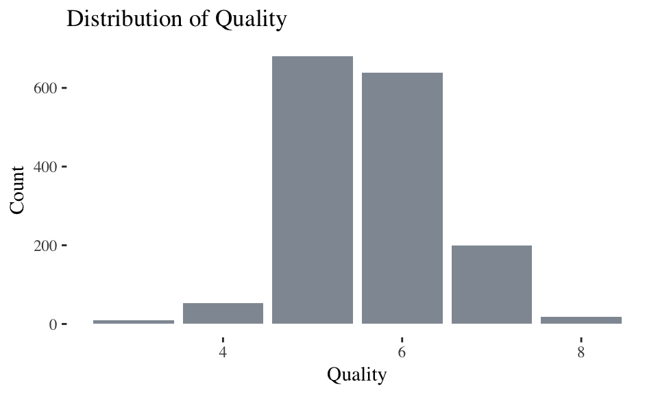

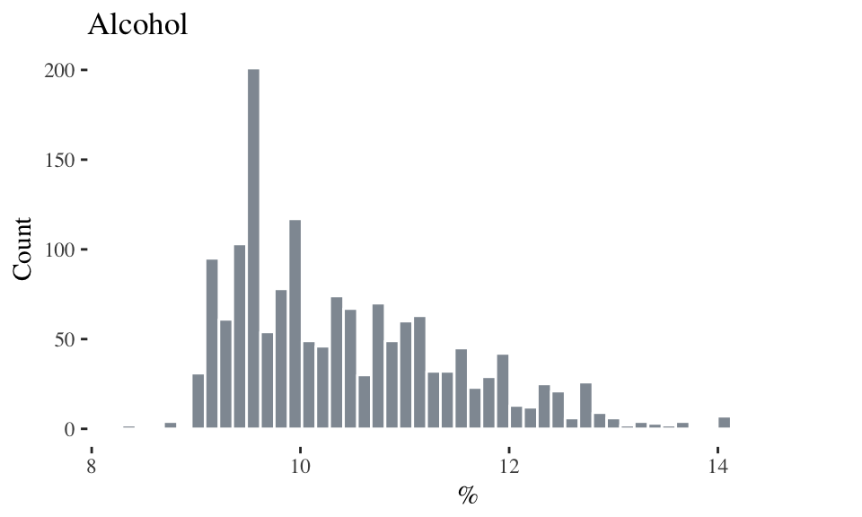

Alcohol also has a skewed distribution of values but with most values located between 9% and 13%. A small histogram can give a quick impression of the distribution of data more effectively than reading the descriptive statistics.

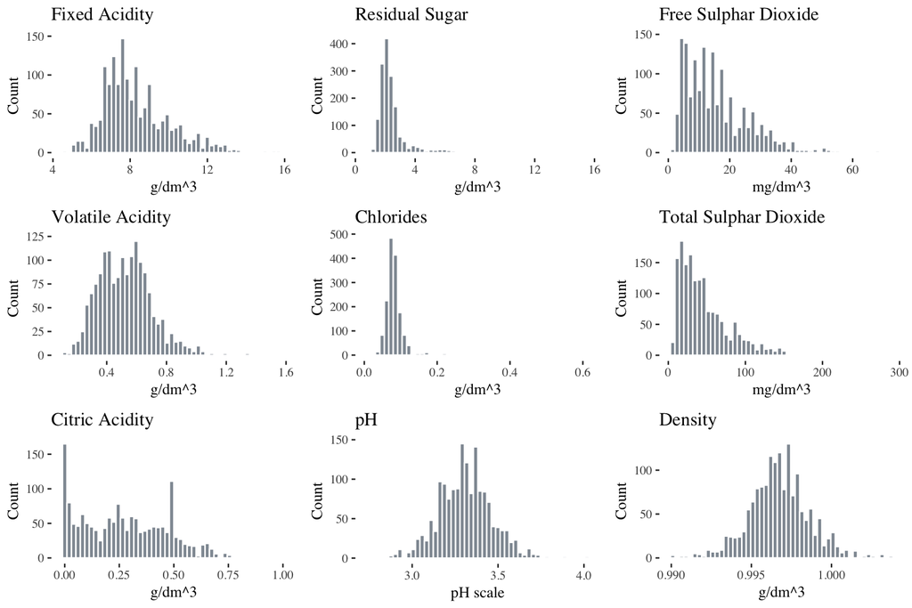

Starting to investigate further variables a group of 9 measurements are placed into histograms to understand their distributions. Of these pH, Fixed acidity and Volatile Acidity have slightly normal distributions, these could be investigated further using quantile quantile plots.

Residual Sugar and Chlorides both appear to have highly skewed, over dispersed data, these could be explored using a transformation to investigate the distribution of values further.

Citric Acidity has two spikes, one occuring at 0 and one around 0.5. Bin size could be changed to investigate if there is some artifact in the data related to rounding.

Density appears relatively normal but with occasional spikes, these should be checked for rounding issues.

Free sulphar dioxide and total sulphar dioxide have skewed distributions, with a sparse population of values towards the maximum.

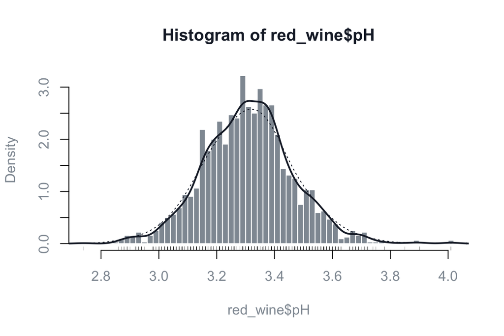

Two plots detailing pH value.

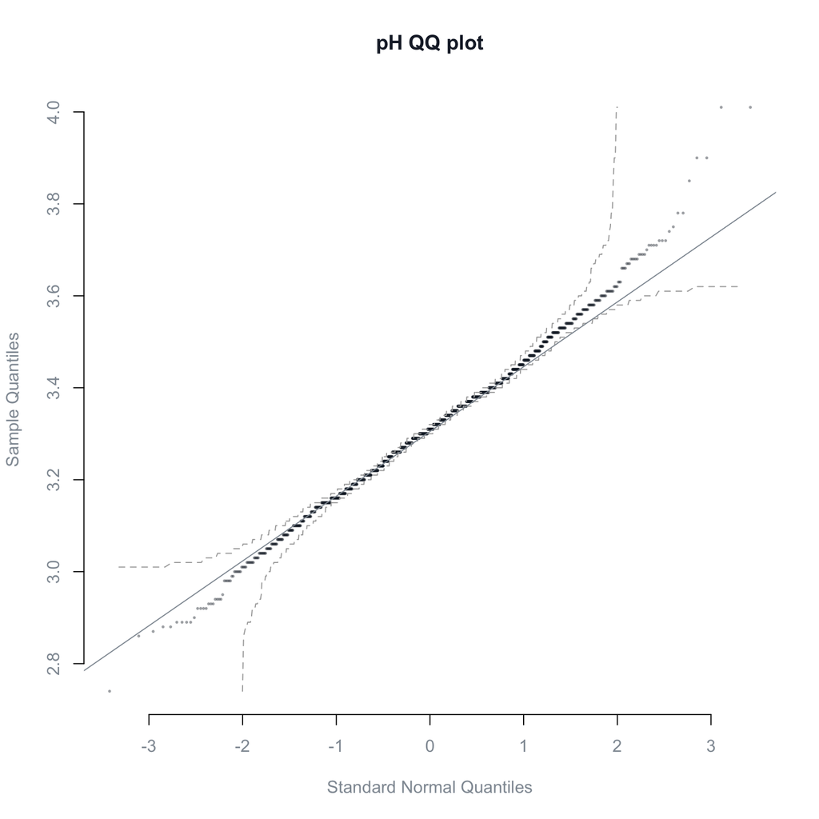

Towards the upper right of the quantile quantile plot against a standard normal distribution the line crosses the 95% confidence intervals.

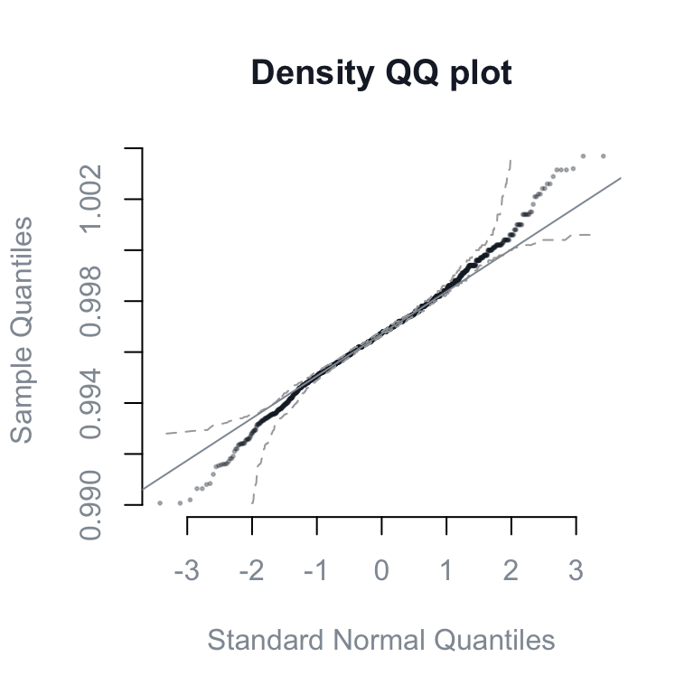

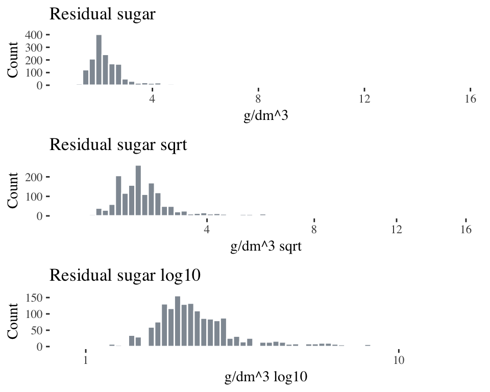

To explore over disperssed variables data transformations can be applied. The original plot followed by a square root and log10 data transformation is conducted on residual sugar in the above three plots. The data transformations give a better representation of the distribution of values. They still have long tails towards the right.

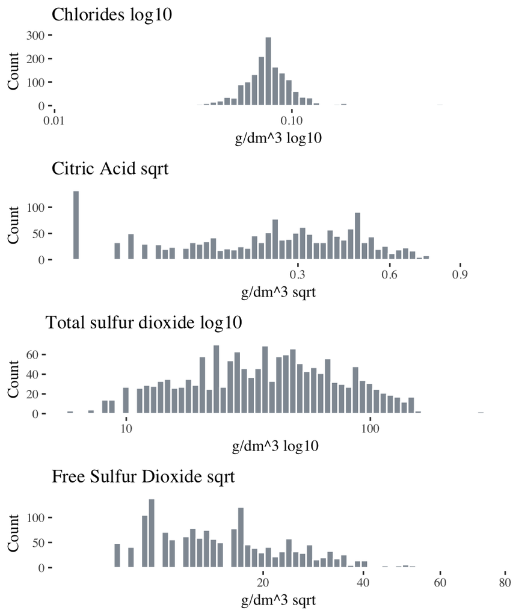

Other over disperssed variables are explored in the above plot and each is matched to a data transformation that better represents the distribution of data values. Chlorides shows a slightly normal distribution with a long tail to the right, it is centered nicely after a log10 transformation.

Citric acid still has a large count of values at close to 0, the data distribution is best represented using a square root transformation, this does not bring the data closer to a normal distribution but represents the the distribution of values across the range.

Total sulfur dioxide is transformed using log10 given a wide normal styled distribution.

Free sulfure dioxide puts too many values to the right hand side during a log10 transformation so even with a skew, square root gives a better distribution of values.

Each of these transformations can be used when comparing these variables to other variables.

# Univariate Analysis

### What is the structure of your dataset?

### What is/are the main feature(s) of interest in your dataset?

### What other features in the dataset do you think will help support your investigation into your feature(s) of interest?

### Did you create any new variables from existing variables in the dataset?

### Of the features you investigated, were there any unusual distributions? Did you perform any operations on the data to tidy, adjust, or change the form of the data? If so, why did you do this?

# Bivariate Plots Section

[figure not shown]

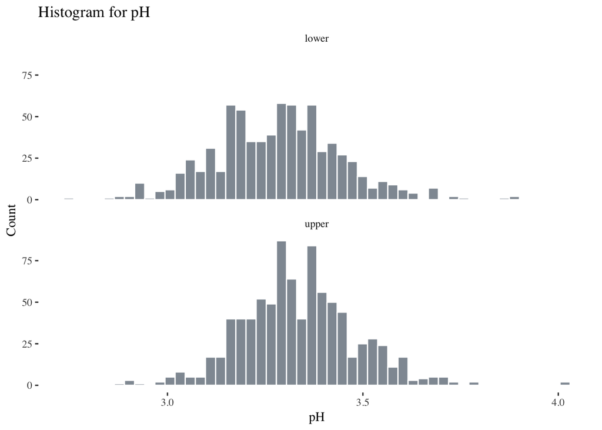

# Bivariate Analysis

### Talk about some of the relationships you observed in this part of the investigation. How did the feature(s) of interest vary with other features in the dataset?

### Did you observe any interesting relationships between the other features (not the main feature(s) of interest)?

### What was the strongest relationship you found?

# Multivariate Plots Section

# Multivariate Analysis

### Talk about some of the relationships you observed in this part of the investigation. Were there features that strengthened each other in terms of looking at your feature(s) of interest?

### Were there any interesting or surprising interactions between features?

### OPTIONAL: Did you create any models with your dataset? Discuss the strengths and limitations of your model.

# Final Plots and Summary

### Description Three

# Reflection

# Resources used

P. Cortez, A. Cerdeira, F. Almeida, T. Matos and J. Reis. Modeling wine preferences by data mining from physicochemical properties. In Decision Support Systems, Elsevier, 47(4):547-553. ISSN: 0167-9236. Available at: [@Elsevier](http://dx.doi.org/10.1016/j.dss.2009.05.016) [Pre-press (pdf)](http://www3.dsi.uminho.pt/pcortez/winequality09.pdf) bib

[ggthemes](https://cran.r-project.org/web/packages/ggthemes/vignettes/ggthemes.html)